# R Diamonds Dataset

Bibek Sapkota

# Install and Import ggplot2, factoextra and psych packages

```r
packages_to_install <- c("ggplot2", "factoextra","psych")

for (package_name in packages_to_install) {
  if (!requireNamespace(package_name, quietly = TRUE)) {
    install.packages(package_name)
  }
}

library(ggplot2)
library(factoextra)
library(psych)
```

# Loading the data into R

```r
data("diamonds")
```

task 1: Displaying first 6 rows data

```r
head(diamonds)
```

| carat | cut | color | clarity | depth | table | price | x | y | z |
| --- | --- | --- | --- | --- | --- | --- | --- | --- | --- |
| 0.23 | Ideal | E | SI2 | 61.5 | 55 | 326 | 3.95 | 3.98 | 2.43 |
| 0.21 | Premium | E | SI1 | 59.8 | 61 | 326 | 3.89 | 3.84 | 2.31 |
| 0.23 | Good | E | VS1 | 56.9 | 65 | 327 | 4.05 | 4.07 | 2.31 |
| 0.29 | Premium | I | VS2 | 62.4 | 58 | 334 | 4.20 | 4.23 | 2.63 |
| 0.31 | Good | J | SI2 | 63.3 | 58 | 335 | 4.34 | 4.35 | 2.75 |
| 0.24 | Very Good | J | VVS2 | 62.8 | 57 | 336 | 3.94 | 3.96 | 2.48 |

task 2: Displaying last 6 rows of data

```r
tail(diamonds)
```

| carat | cut | color | clarity | depth | table | price | x | y | z |
| --- | --- | --- | --- | --- | --- | --- | --- | --- | --- |
| 0.72 | Premium | D | SI1 | 62.7 | 59 | 2757 | 5.69 | 5.73 | 3.58 |
| 0.72 | Ideal | D | SI1 | 60.8 | 57 | 2757 | 5.75 | 5.76 | 3.50 |
| 0.72 | Good | D | SI1 | 63.1 | 55 | 2757 | 5.69 | 5.75 | 3.61 |
| 0.70 | Very Good | D | SI1 | 62.8 | 60 | 2757 | 5.66 | 5.68 | 3.56 |
| 0.86 | Premium | H | SI2 | 61.0 | 58 | 2757 | 6.15 | 6.12 | 3.74 |
| 0.75 | Ideal | D | SI2 | 62.2 | 55 | 2757 | 5.83 | 5.87 | 3.64 |

task 3: Displaying more than 6 rows of data

```r
head(diamonds,10)
```

| carat | cut | color | clarity | depth | table | price | x | y | z |
| --- | --- | --- | --- | --- | --- | --- | --- | --- | --- |
| 0.23 | Ideal | E | SI2 | 61.5 | 55 | 326 | 3.95 | 3.98 | 2.43 |
| 0.21 | Premium | E | SI1 | 59.8 | 61 | 326 | 3.89 | 3.84 | 2.31 |
| 0.23 | Good | E | VS1 | 56.9 | 65 | 327 | 4.05 | 4.07 | 2.31 |
| 0.29 | Premium | I | VS2 | 62.4 | 58 | 334 | 4.20 | 4.23 | 2.63 |
| 0.31 | Good | J | SI2 | 63.3 | 58 | 335 | 4.34 | 4.35 | 2.75 |
| 0.24 | Very Good | J | VVS2 | 62.8 | 57 | 336 | 3.94 | 3.96 | 2.48 |
| 0.24 | Very Good | I | VVS1 | 62.3 | 57 | 336 | 3.95 | 3.98 | 2.47 |
| 0.26 | Very Good | H | SI1 | 61.9 | 55 | 337 | 4.07 | 4.11 | 2.53 |
| 0.22 | Fair | E | VS2 | 65.1 | 61 | 337 | 3.87 | 3.78 | 2.49 |
| 0.23 | Very Good | H | VS1 | 59.4 | 61 | 338 | 4.00 | 4.05 | 2.39 |

task 4: Checking the structure of data

```r
str(diamonds)
```

```
tibble [53,940 × 10] (S3: tbl_df/tbl/data.frame)
 $ carat  : num [1:53940] 0.23 0.21 0.23 0.29 0.31 0.24 0.24 0.26 0.22 0.23 ...
 $ cut    : Ord.factor w/ 5 levels "Fair"<"Good"<..: 5 4 2 4 2 3 3 3 1 3 ...
 $ color  : Ord.factor w/ 7 levels "D"<"E"<"F"<"G"<..: 2 2 2 6 7 7 6 5 2 5 ...
 $ clarity: Ord.factor w/ 8 levels "I1"<"SI2"<"SI1"<..: 2 3 5 4 2 6 7 3 4 5 ...
 $ depth  : num [1:53940] 61.5 59.8 56.9 62.4 63.3 62.8 62.3 61.9 65.1 59.4 ...
 $ table  : num [1:53940] 55 61 65 58 58 57 57 55 61 61 ...
 $ price  : int [1:53940] 326 326 327 334 335 336 336 337 337 338 ...
 $ x      : num [1:53940] 3.95 3.89 4.05 4.2 4.34 3.94 3.95 4.07 3.87 4 ...
 $ y      : num [1:53940] 3.98 3.84 4.07 4.23 4.35 3.96 3.98 4.11 3.78 4.05 ...
 $ z      : num [1:53940] 2.43 2.31 2.31 2.63 2.75 2.48 2.47 2.53 2.49 2.39 ...
```

task 5: Checking the dimension of data

```r
dim(diamonds)
```

```
[1] 53940    10
```

task 6: Summarizing the data

```r
summary(diamonds)
```

```
     carat               cut        color        clarity          depth           table
 Min.   :0.2000   Fair     : 1610   D: 6775   SI1    :13065   Min.   :43.00   Min.   :43.00
 1st Qu.:0.4000   Good     : 4906   E: 9797   VS2    :12258   1st Qu.:61.00   1st Qu.:56.00
 Median :0.7000   Very Good:12082   F: 9542   SI2    : 9194   Median :61.80   Median :57.00
 Mean   :0.7979   Premium  :13791   G:11292   VS1    : 8171   Mean   :61.75   Mean   :57.46
 3rd Qu.:1.0400   Ideal    :21551   H: 8304   VVS2   : 5066   3rd Qu.:62.50   3rd Qu.:59.00
 Max.   :5.0100                     I: 5422   VVS1   : 3655   Max.   :79.00   Max.   :95.00
                                    J: 2808   (Other): 2531
     price             x                y                z
 Min.   :  326   Min.   : 0.000   Min.   : 0.000   Min.   : 0.000
 1st Qu.:  950   1st Qu.: 4.710   1st Qu.: 4.720   1st Qu.: 2.910
 Median : 2401   Median : 5.700   Median : 5.710   Median : 3.530
 Mean   : 3933   Mean   : 5.731   Mean   : 5.735   Mean   : 3.539
 3rd Qu.: 5324   3rd Qu.: 6.540   3rd Qu.: 6.540   3rd Qu.: 4.040
 Max.   :18823   Max.   :10.740   Max.   :58.900   Max.   :31.800
```

task 7: Describing the data

```r
 describe(diamonds)
```

|  | vars | n | mean | sd | median | trimmed | mad | min | max | range | skew | kurtosis | se |
| --- | --- | --- | --- | --- | --- | --- | --- | --- | --- | --- | --- | --- | --- |
| carat | 1 | 53940 | 0.80 | 0.47 | 0.70 | 0.73 | 0.47 | 0.2 | 5.01 | 4.81 | 1.12 | 1.26 | 0.00 |
| cut* | 2 | 53940 | 3.90 | 1.12 | 4.00 | 4.04 | 1.48 | 1.0 | 5.00 | 4.00 | -0.72 | -0.40 | 0.00 |
| color* | 3 | 53940 | 3.59 | 1.70 | 4.00 | 3.55 | 1.48 | 1.0 | 7.00 | 6.00 | 0.19 | -0.87 | 0.01 |
| clarity* | 4 | 53940 | 4.05 | 1.65 | 4.00 | 3.91 | 1.48 | 1.0 | 8.00 | 7.00 | 0.55 | -0.39 | 0.01 |
| depth | 5 | 53940 | 61.75 | 1.43 | 61.80 | 61.78 | 1.04 | 43.0 | 79.00 | 36.00 | -0.08 | 5.74 | 0.01 |
| table | 6 | 53940 | 57.46 | 2.23 | 57.00 | 57.32 | 1.48 | 43.0 | 95.00 | 52.00 | 0.80 | 2.80 | 0.01 |
| price | 7 | 53940 | 3932.80 | 3989.44 | 2401.00 | 3158.99 | 2475.94 | 326.0 | 18823.00 | 18497.00 | 1.62 | 2.18 | 17.18 |
| x | 8 | 53940 | 5.73 | 1.12 | 5.70 | 5.66 | 1.38 | 0.0 | 10.74 | 10.74 | 0.38 | -0.62 | 0.00 |
| y | 9 | 53940 | 5.73 | 1.14 | 5.71 | 5.66 | 1.36 | 0.0 | 58.90 | 58.90 | 2.43 | 91.20 | 0.00 |
| z | 10 | 53940 | 3.54 | 0.71 | 3.53 | 3.49 | 0.85 | 0.0 | 31.80 | 31.80 | 1.52 | 47.08 | 0.00 |

# Visualization of diamonds dataset

task 1:Building the histogram of carat

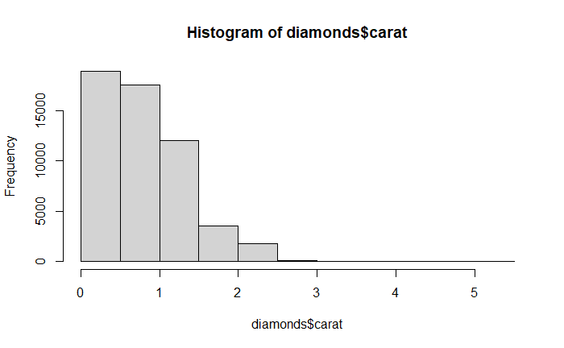

```r
hist(diamonds$carat)
```

task 2:Using color to color the bin

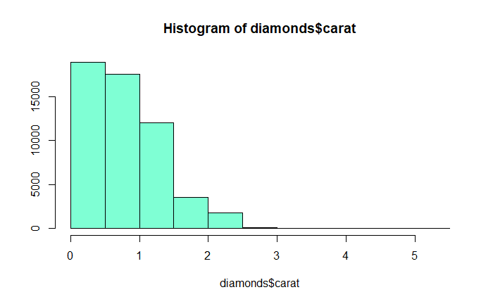

```r
hist(diamonds$carat, col='aquamarine', ylab = "")
```

task 3:Changing the label of x-axis

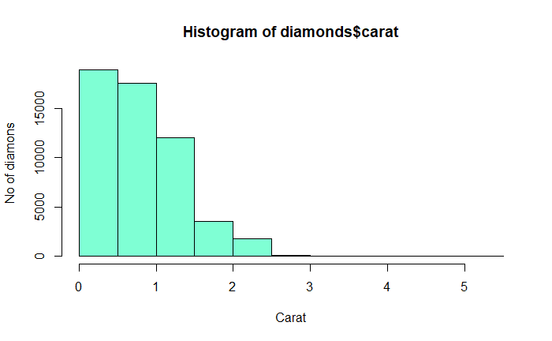

```r
 hist(diamonds$carat, col='aquamarine', xlab = "Carat", ylab= "No of diamons")
```

task 4: Creating a box plot of all variables in dataset

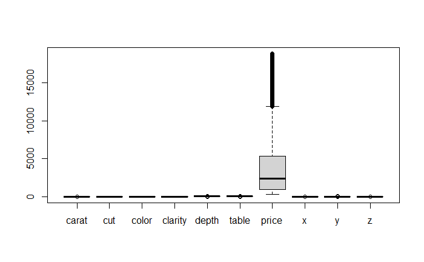

```r
boxplot(diamonds)
```

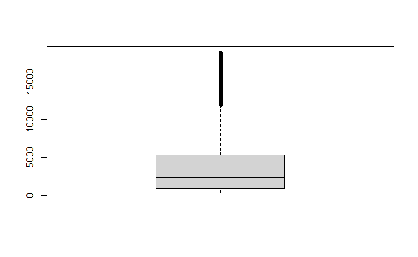

```r
boxplot(diamonds$price)
```

task 6:Filling in the label on x-axis and y-axis

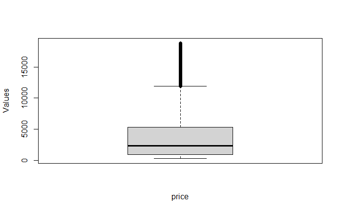

```r
boxplot(diamonds$price,
        xlab="price",
        ylab="Values")
```

task 7:Displaying Boxplot

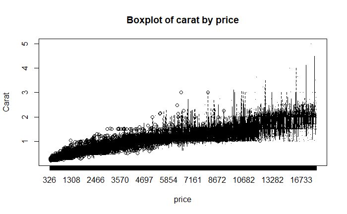

```r
 boxplot(carat ~ price , data = diamonds,
 xlab = "price",
 ylab = "Carat",
 main = "Boxplot of carat by price")
```

task 8:Plotting the Scatter plot

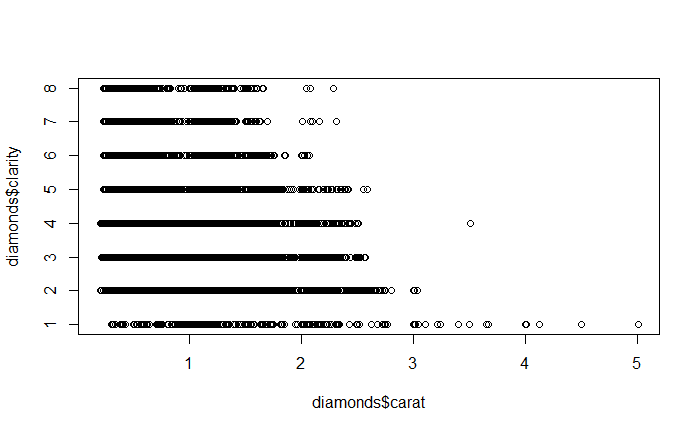

```r
 plot(diamonds$carat, diamonds$clarity)
```

```r
trans_dist <- table(diamonds$color)
```

task 10:Creating pie chart

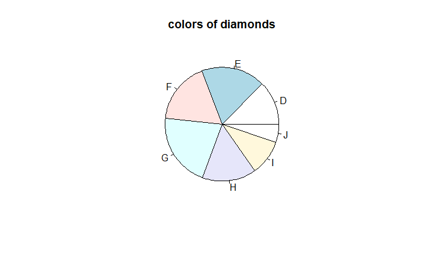

```r
pie(trans_dist,
 labels = c("D","E","F", "G","H" , "I", "J"),
 main = "colors of diamonds")
```

task 11:Using Scatter plot matrix for Displaying selected variables

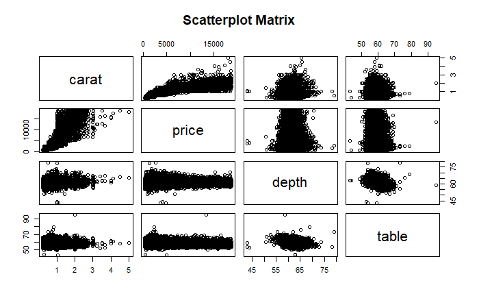

```r
pairs(diamonds[, c("carat", "price", "depth", "table")],
 main = "Scatterplot Matrix")
```

task 12:Ploting Histogram of carat

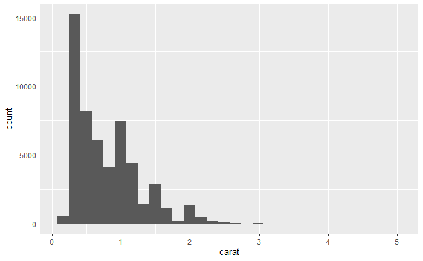

```r
ggplot(diamonds, aes(x = carat),) +
 geom_histogram()
```

task 13:Using color to color the bin

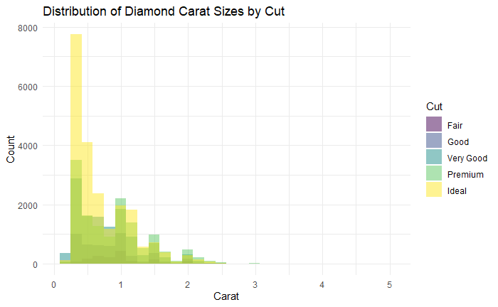

```r
ggplot(diamonds, aes(x = carat, fill = cut)) +
  geom_histogram(bins = 30, position = "identity", alpha = 0.5) +
  theme_minimal() +
  labs(title = "Distribution of Diamond Carat Sizes by Cut",
       x = "Carat",
       y = "Count",
       fill = "Cut")
```

task 14:Changing the label of x-axis

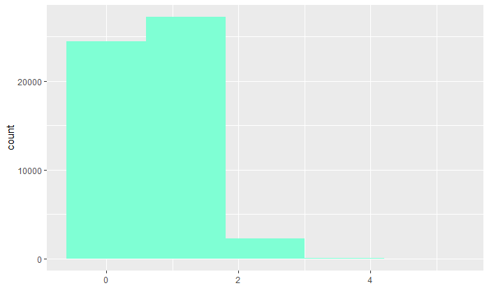

```r
ggplot(diamonds, aes(x = carat)) +
 geom_histogram(fill = 'aquamarine', bins = 5) +
 xlab("")
```

task 15:Createing the box plot of only single variable

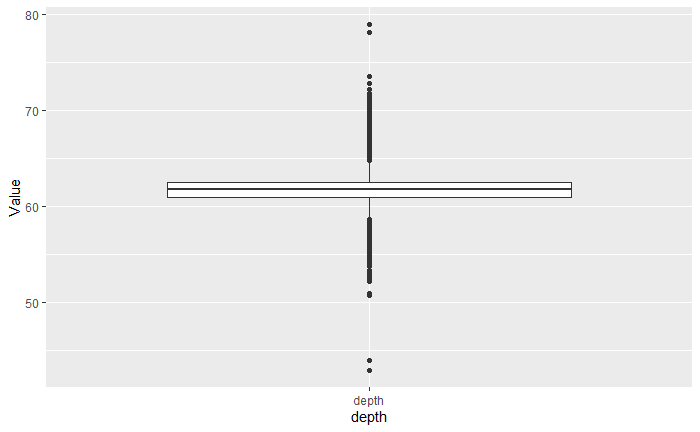

```r
ggplot(diamonds, aes(x= factor('depth'),y=depth)) +
 geom_boxplot()+
 ylab("Value") +
 xlab("depth")
```

[figure not shown]

```r
 ggplot(diamonds, aes(x= factor(cut),y=color))+
 geom_boxplot()+
 xlab("carat") +
 ylab("price") +
 ggtitle("Box plot of carat by price")
```

task 17: Ploting the Scatter Plot

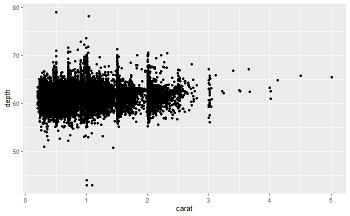

```r
 ggplot(diamonds, aes(x = carat, y = depth)) +
 geom_point()
```

# Applying K-means Clustering

task 1:set random seed

```r
set.seed(7696)
```

task 2: checking the class and dimension of data

```r
class(diamonds)
```

```
[1] "tbl_df"     "tbl"        "data.frame"
```

```r
dim(diamonds)
```

```
[1] 53940    10
```

task 3:filter data by column name

```r
filtered_data1= diamonds[, c("price","carat")]
```

task 4:Visualizing the data

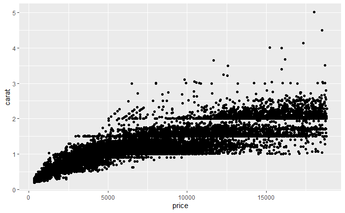

```r
ggplot(diamonds, aes(x= price, y= carat))+
  geom_point()
```

task 5:Finding 5 clusters using k-means clustering and viewing the details

```r
clusters=kmeans(filtered_data1, 5)
clusters
```

[output not shown]

task 6: Visulizing the cluster

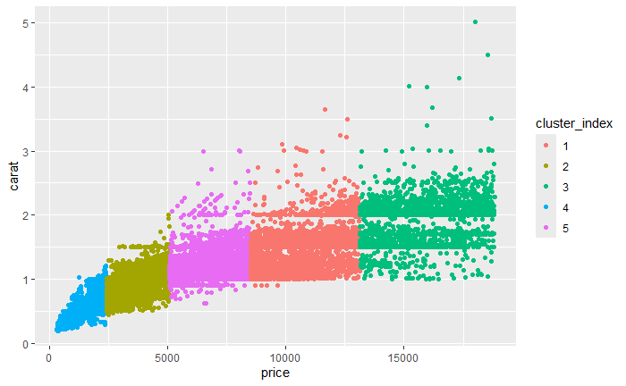

```r
cluster_index = as.factor(clusters$cluster)
ggplot(filtered_data1, aes(x=price, y=carat, color= cluster_index )) +
  geom_point()
```

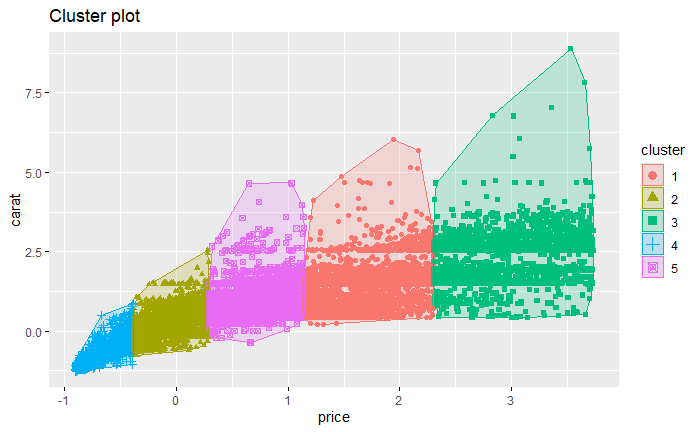

```r
fviz_cluster(clusters, data= filtered_data1, geom= c("point"))
```

task 7:Filtering the data

```r
filtered_data2= diamonds[, c("depth","price","carat")]
```

task 9:Finding 5 clusters using k-means clustering and viewing the details

```r
cluster2= kmeans(filtered_data2, 5)
cluster2
```

[output not shown]

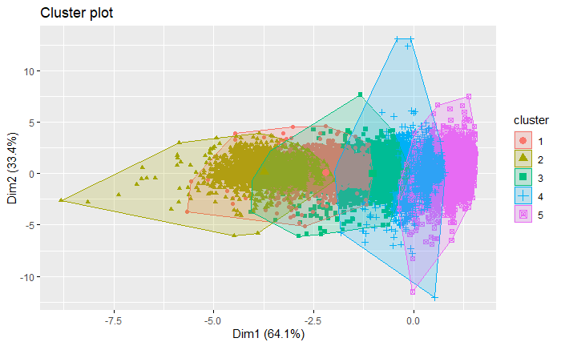

```r
fviz_cluster(cluster2, data= filtered_data2, geom= c("point"))
```

task 11:Finding 5 clusters using k-means clustering and viewing the details

```r
cluster3= kmeans(filtered_data2, 5 , nstart=25)
cluster3
```

[output not shown]

task 12:Visulizing the cluster

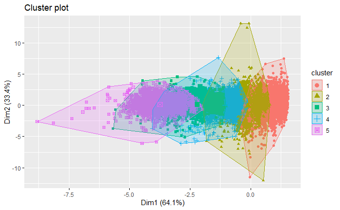

```r
fviz_cluster(cluster3, data= filtered_data2, geom= c("point"))
```